# Clean-Eating in Manhattan

#### (4) More VF restaurants than others: Clinton Neighborhood

Clinton and East Village, where vegetarian food is more accessible, are also the proper and good quality areas for enjoying a healthy meal. The pattern of the price level and rating score are similar to all the zip tracts in Manhattan. The food there is more affordable and highly recommended by customers on the Yelp platform. For example, Chinese cuisines are popular and denser in the southern part of the East Village, where Chinatown is located. Tofu, mushrooms, vegetables, and noodle soup are typical dishes. Even with fewer ingredients, people who like to eat clean still have a large number of choices.

Living in Manhattan is luck for clean-eating customers. Colorful ingredients, healthy cooking methods, and various recipes… Do these attract you? Does your moth keep watering now? Let’s go for a “green” bite, explore our neighborhoods and get the party started!

```python
df['zipcode'].value_counts().idxmax()
```

```
10019
```

```python
# 10019 Chelsea and Clinton, around Columbus Circles
```

```python
Clinton = df.loc[df['zipcode'] == 10019]
Clinton.head()
```

|  | name | latitude | longitude | zipcode | price | rating | review_count | Price_num |
| --- | --- | --- | --- | --- | --- | --- | --- | --- |
| 11 | Beyond Sushi | 40.763310 | -73.977170 | 10019 | $$ | 4.5 | 675 | 2.0 |
| 13 | MTHR Vegan | 40.762410 | -73.988060 | 10019 | $$ | 4.5 | 230 | 2.0 |
| 29 | Westville Hell's Kitchen | 40.765770 | -73.987500 | 10019 | $$ | 4.5 | 118 | 2.0 |
| 34 | wagamama - midtown | 40.762900 | -73.978157 | 10019 | $$ | 4.5 | 31 | 2.0 |
| 47 | Bengal Tiger Indian Food | 40.763167 | -73.977131 | 10019 | $$ | 4.5 | 1891 | 2.0 |

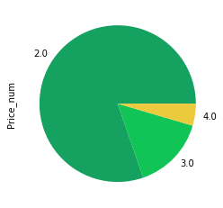

```python
colors = ['#15a15f', '#10c455', '#ebcb3d', '#f7f37c']
Count_price1 = Clinton['Price_num'].value_counts().sort_index().plot(kind='pie', colors=colors)
plt.show()
```

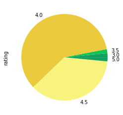

```python
colors = ['#15a15f', '#10c455', '#ebcb3d', '#f7f37c']
Count_rating1 = Clinton['rating'].value_counts().sort_index().plot(kind='pie', colors=colors)
plt.show()
```

```python
East_Village = df.loc[df['zipcode'] == 10003]
East_Village.head()
```

|  | name | latitude | longitude | zipcode | price | rating | review_count | Price_num |
| --- | --- | --- | --- | --- | --- | --- | --- | --- |
| 2 | Spicy Moon East Village | 40.726740 | -73.987220 | 10003 | $$ | 4.5 | 291 | 2.0 |
| 19 | Nix | 40.733230 | -73.993590 | 10003 | $$ | 4.0 | 550 | 2.0 |
| 23 | Bali Kitchen | 40.725371 | -73.987617 | 10003 | $$ | 4.5 | 137 | 2.0 |
| 28 | Divya's Kitchen | 40.723780 | -73.988490 | 10003 | $$ | 4.5 | 366 | 2.0 |
| 35 | Thai Villa | 40.739020 | -73.990650 | 10003 | $$ | 4.5 | 3318 | 2.0 |

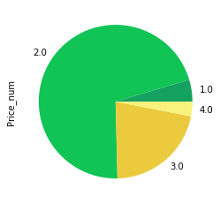

```python
colors = ['#15a15f', '#10c455', '#ebcb3d', '#f7f37c']
Count_price2 = East_Village['Price_num'].value_counts().sort_index().plot(kind='pie', colors=colors)
plt.show()
```

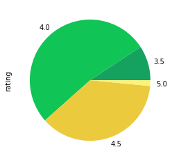

```python
colors = ['#15a15f', '#10c455', '#ebcb3d', '#f7f37c']
Count_rating2 = East_Village['rating'].value_counts().sort_index().plot(kind='pie', colors=colors)
plt.show()
```

Reference: [1] Why people in rich countries are eating more vegan food. (n.d.). Retrieved from https://www.economist.com/briefing/2018/10/13/why-people-in-rich-countries-are-eating-more-vegan-food. [2] Corsetti, S. (n.d.). The vegan movement is elitist. Retrieved from https://dailycollegian.com/2018/02/the-vegan-movement-is-elitist/. [3] Dean, M. (2014). You Are How You Eat? Femininity, Normalization, and Veganism as an Ethical Practice of Freedom. Societies, 4(2), 127–147. doi: 10.3390/soc4020127 [4] Sun, Y., & Paule, J. D. G. (2017). Spatial analysis of users-generated ratings of yelp venues. Open Geospatial Data, Software and Standards, 2(1). doi: 10.1186/s40965–017–0020–9 [5] Glaeser, E. L., Kim, H., & Luca, M. (2018). Nowcasting Gentrification: Using Yelp Data to Quantify Neighborhood Change. SSRN Electronic Journal. doi: 10.2139/ssrn.3123733 [6] Dean, M. (2014). You Are How You Eat? Femininity, Normalization, and Veganism as an Ethical Practice of Freedom. Societies, 4(2), 127–147. doi: 10.3390/soc4020127 [7] Glaeser, E. L., Kim, H., & Luca, M. (2017). Nowcasting the Local Economy: Using Yelp Data to Measure Economic Activity at Scale. SSRN Electronic Journal. doi: 10.2139/ssrn.3037603 [8] Oberst, L., & Oberst, L. (2018, January 18). Why the Global Rise in Vegan and Plant-Based Eating Isn't A Fad (600% Increase in U.S. Vegans Other Astounding Stats). Retrieved from https://foodrevolution.org/blog/vegan-statistics-global/.